# # Reproducible Research Week 2 Assignment

## Task 1: Loading and preprocessing the data

- Downloading the data
- Unzipping the original data file
- Loading the data into an ‘R’ object via the read.csv() funtion.

```r
knitr::opts_chunk$set(echo = TRUE)
download.file(url = "https://d396qusza40orc.cloudfront.net/repdata%2Fdata%2Factivity.zip",destfile = "Rep Research Week2.zip")
data <- read.csv(unzip("Rep Research Week2.zip"))
```

## Task 2: What is mean total number of steps taken per day

2.1 Calculate the total number of steps taken per day

```r
data_noNA <- data[!is.na(data$'steps'),]

#using an SQL style query to create a dataframe containing average steps per day by date.
library(sqldf)
total_steps_perday <- sqldf("select sum(steps),date from data_noNA group by date")
colnames(total_steps_perday) <- c("steps","date")
#The total number of steps per day is:
total_steps_perday
```

```
##    steps       date
## 1    126 2012-10-02
## 2  11352 2012-10-03
## 3  12116 2012-10-04
## 4  13294 2012-10-05
## 5  15420 2012-10-06
## 6  11015 2012-10-07
## 7  12811 2012-10-09
## 8   9900 2012-10-10
## 9  10304 2012-10-11
## 10 17382 2012-10-12
## 11 12426 2012-10-13
## 12 15098 2012-10-14
## 13 10139 2012-10-15
## 14 15084 2012-10-16
```

[output cut: 39 more lines]

2.2 Make a histogram of the total number of steps taken each day

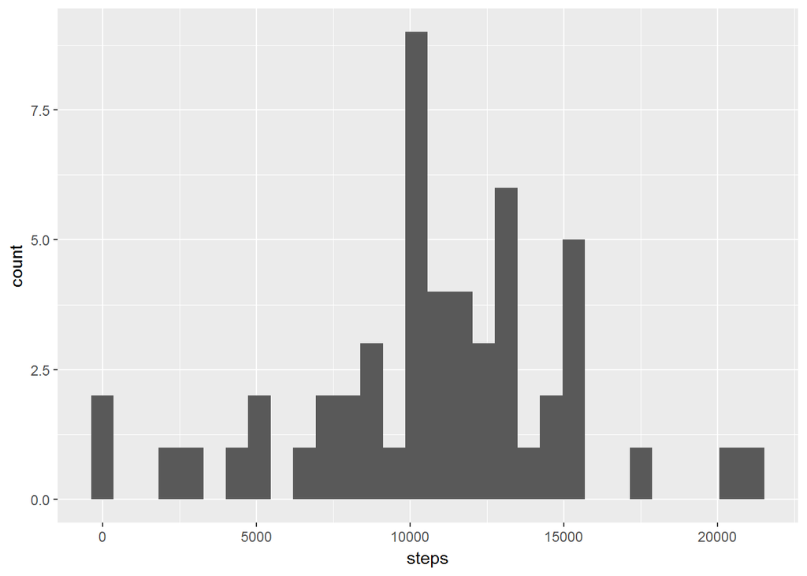

```r
library(ggplot2)
ggplot(data=total_steps_perday) + geom_histogram(mapping = aes(x= steps))
```

```r
mean <- mean(total_steps_perday$steps)
median <- median(total_steps_perday$steps)
```

## Task 3: What is the average daily activity pattern?

3.1 Make a time series plot (i.e. type = “l”) of the 5-minute interval (x-axis) and the average number of steps taken, averaged across all days (y-axis)

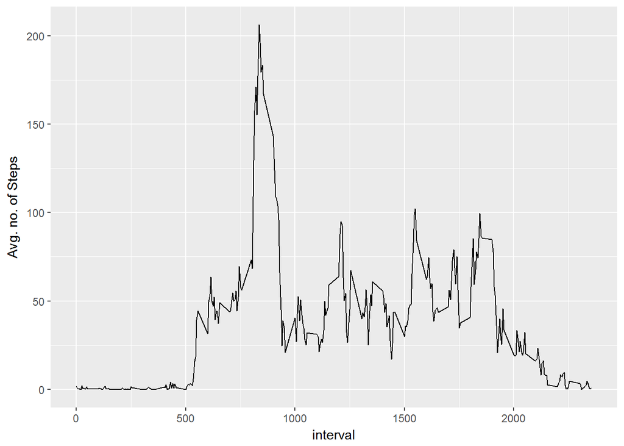

```r
average_steps_perinterval <- sqldf("select avg(steps),interval,count(*) from data_noNA group by interval")
colnames(average_steps_perinterval) <- c("avg_steps","interval","count")

## The followiing graph depicts thew timeseries plot of average no. of steps across various 5 minute intervals.
ggplot(average_steps_perinterval, aes(interval, avg_steps)) + geom_line() + ylab("Avg. no. of Steps") + xlab("interval")
```

3.2 Which 5-minute interval, on average across all the days in the dataset, contains the maximum number of steps?

```r
max_average_interval <- average_steps_perinterval[max(average_steps_perinterval$'avg_steps'),]
max_average_interval
```

[output not shown]

## Task 4: Imputing missing values

4.1 Calculate and report the total number of missing values in the dataset (i.e. the total number of rows with NAs)

```r
data_NAs <- data[is.na(data$'steps'),]
number_of_NAs <- nrow(data_NAs)
number_of_NAs
```

```
## [1] 2304
```

The total number of NAs is 2304

4.2 Devise a strategy for filling in all of the missing values in the dataset. The strategy does not need to be sophisticated. For example, you could use the mean/median for that day, or the mean for that 5-minute interval, etc.

```r
replace_NAs <- data_NAs
average_steps_perday1 <- sqldf("select avg(steps),interval from data_noNA group by interval")
colnames(average_steps_perday1) <- c("steps2","interval")

replace_NAs_final <- sqldf("select a.steps, a.date, a.interval, b.steps2 from replace_NAs a left join average_steps_perday1 b on a.interval = b.interval")
replace_NAs_final1 <- as.data.frame(cbind(replace_NAs_final$steps2,as.character(replace_NAs_final$date),replace_NAs_final$interval))
colnames(replace_NAs_final1) <- colnames(data)
```

4.3 Create a new dataset that is equal to the original dataset but with the missing data filled in.

```r
reconstructed <- rbind(data_noNA,replace_NAs_final1)
```

```r
library(ggplot2)
library(sqldf)
total_steps_imputed <- sqldf("select sum(steps),date from reconstructed group by date")
# The total number of steps per day (after imputing NAs) is:
total_steps_imputed
```

```
##    sum(steps)       date
## 1    10766.19 2012-10-01
## 2      126.00 2012-10-02
## 3    11352.00 2012-10-03
## 4    12116.00 2012-10-04
## 5    13294.00 2012-10-05
## 6    15420.00 2012-10-06
## 7    11015.00 2012-10-07
## 8    10766.19 2012-10-08
## 9    12811.00 2012-10-09
## 10    9900.00 2012-10-10
## 11   10304.00 2012-10-11
## 12   17382.00 2012-10-12
## 13   12426.00 2012-10-13
## 14   15098.00 2012-10-14
```

[output cut: 47 more lines]

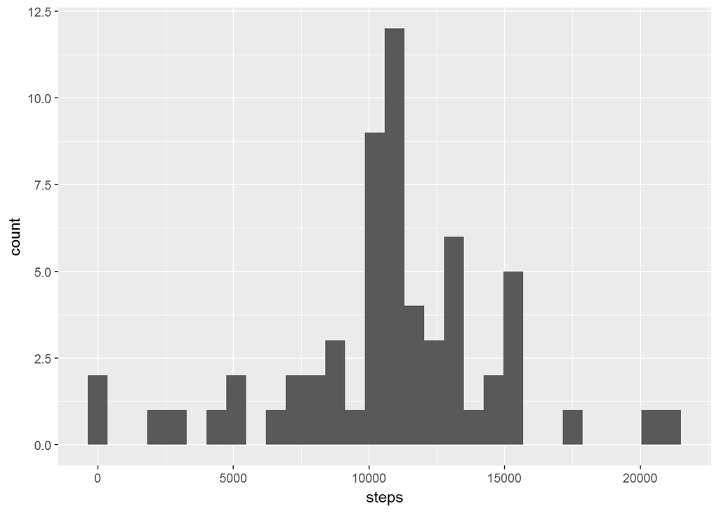

```r
colnames(total_steps_imputed) <- c("steps","date")
# Histogram of total steps after imputing:
ggplot(data=total_steps_imputed) + geom_histogram(mapping = aes(x= steps))
```

## 5. Are there differences in activity patterns between weekdays and weekends?

5.1 Create a new factor variable in the dataset with two levels weekdays and weekends indicating whether a given date is a weekday or weekend day.

```r
weekdays <- reconstructed
weekdays[,"weekday"] <- NA #adding a blank column to use as a weekend/weekday indicator.

#using a custom function along with function sapply() to add a flag called "weekday" that indicates whether
#a row corresponds to a Weekend observation or a Weekday observation.
return_weekday <- function(x){
  if(weekdays(x) %in% c("Saturday","Sunday"))
     {
       return("Weekend")
  }
     return("Weekday")
}

weekdays$weekday <- sapply(as.Date(weekdays$date), function(t) return_weekday(t))
weekdays$steps <- as.numeric(weekdays$steps) #updating the weekday derived, into the data frame
```

5.2 Make a panel plot containing a time series plot (i.e. type = “l”) of the 5-minute interval (x-axis) and the average number of steps taken, averaged across all weekday days or weekend days (y-axis). See the README file in the GitHub repository to see an example of what this plot should look like using simulated data.

```r
library(ggplot2)
library(sqldf)
plot1 <- sqldf("select avg(steps),interval, weekday from weekdays group by interval, weekday")
str(plot1)
```

```
## 'data.frame':    576 obs. of  3 variables:
##  $ avg(steps): num  2.2512 0.2146 0.1732 0.0165 0.4205 ...
##  $ interval  : chr  "0" "0" "10" "10" ...
##  $ weekday   : chr  "Weekday" "Weekend" "Weekday" "Weekend" ...
```

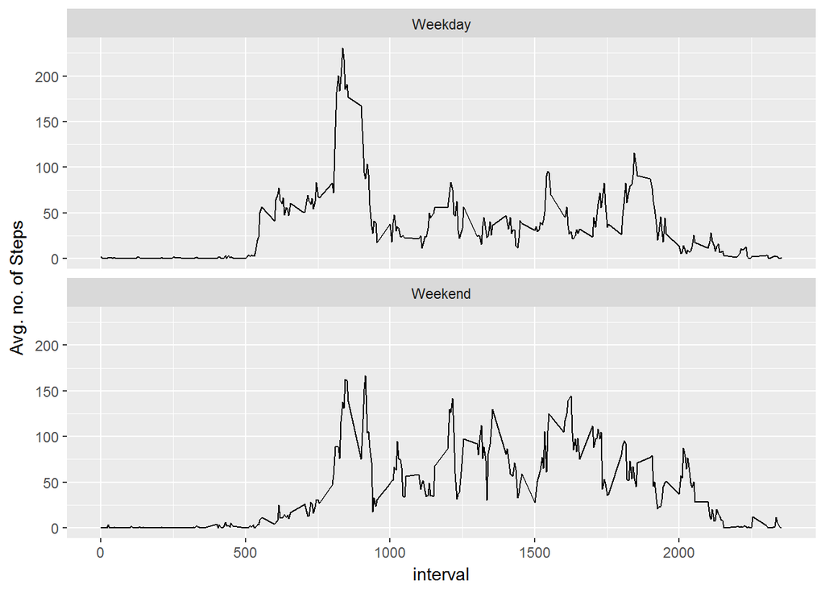

```r
colnames(plot1) <- c("steps","interval","weekday")
ggplot(plot1, aes(as.numeric(interval), steps)) + geom_line() + ylab("Avg. no. of Steps") + xlab("interval") + facet_wrap(~weekday, nrow = 2)
```